# BLAM_Liege_beh_analyses

Jacek Matuszewski

2023-09-08

#BLAM 7T Behavioural analyses: Bimodal Motion

## Subjects:

11 Congenitally Blind 13 Sighted Controls (Some are excluded from analyses in certain tasks due to lack of responses)

## List of tasks:

### Auditory Motion

Stimuli:

Experimental design:

Conditions & Task(s)

- *Motion* (**Press the button for repetition of sound direction**)
- *Static* (**Press the button for repeated double short bursts**)

Subject exclusions

### Visual Motion

Stimuli:

Experimental design:

Conditions & Task(s)

- *Motion* (**Press the button for repetition of sound direction**)
- *Static* (**Press the button for repeated double short bursts**)

Subject exclusions:

## Auditory Motion: behavioural accuracies

### Axis of motion pulled together (motion vs static)

Descriptive statistics across groups and conditions [% correct]

```
## # A tibble: 4 × 4
## # Groups:   group [2]
##   group cond             mean    sd
##   <chr> <fct>           <dbl> <dbl>
## 1 EB    auditory_motion  87.5 14.8
## 2 EB    auditory_static  98.9  3.77
## 3 SC    auditory_motion  72.1 24.0
## 4 SC    auditory_static  96.2  7.88
```

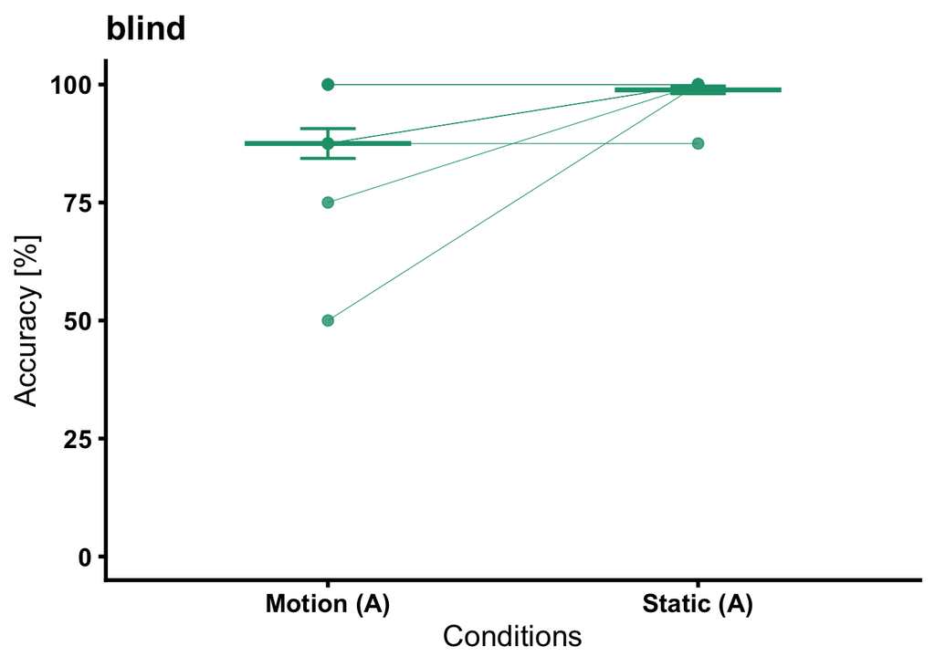

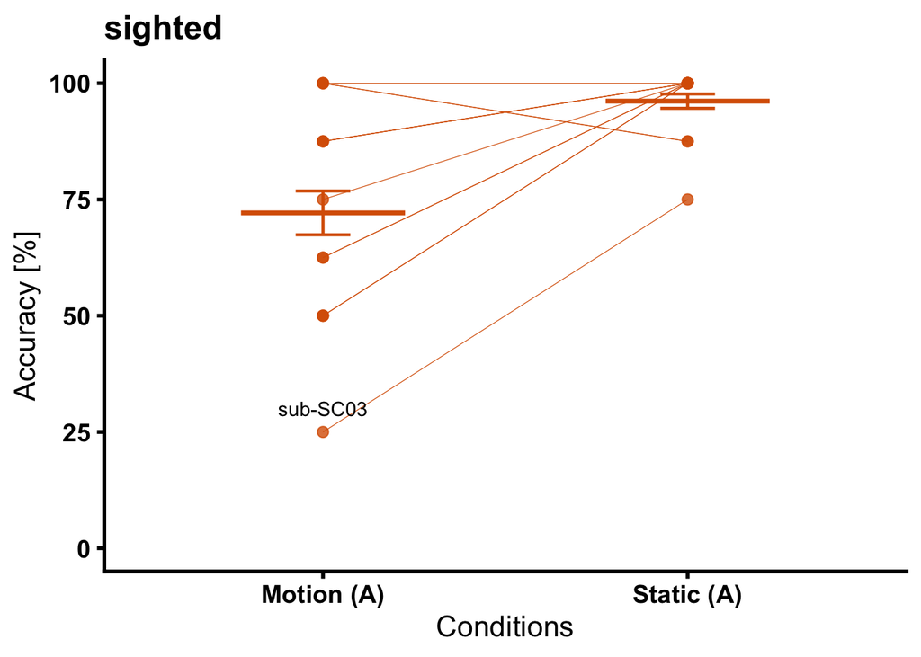

ANOVA 2 (group) x 2 (condition)

```
## $ANOVA
##       Effect DFn DFd         F            p p<.05        ges
## 2      group   1  20  2.788713 0.1105081308       0.07250317
## 3       cond   1  20 15.393825 0.0008412893     * 0.25271907
## 4 group:cond   1  20  1.482939 0.2374880391       0.03155060
```

### Axis of motion separated (vertical vs horizontal)

Descriptive stats

```
## # A tibble: 8 × 5
## # Groups:   group, cond [4]
##   group cond            axis        mean    sd
##   <chr> <fct>           <chr>      <dbl> <dbl>
## 1 EB    auditory_motion horizontal  97.7  7.54
## 2 EB    auditory_motion vertical    77.3 30.5
## 3 EB    auditory_static horizontal  97.7  7.54
## 4 EB    auditory_static vertical   100    0
## 5 SC    auditory_motion horizontal  80.8 29.1
## 6 SC    auditory_motion vertical    63.5 39.0
## 7 SC    auditory_static horizontal  98.1  6.93
## 8 SC    auditory_static vertical    94.2 15.0
```

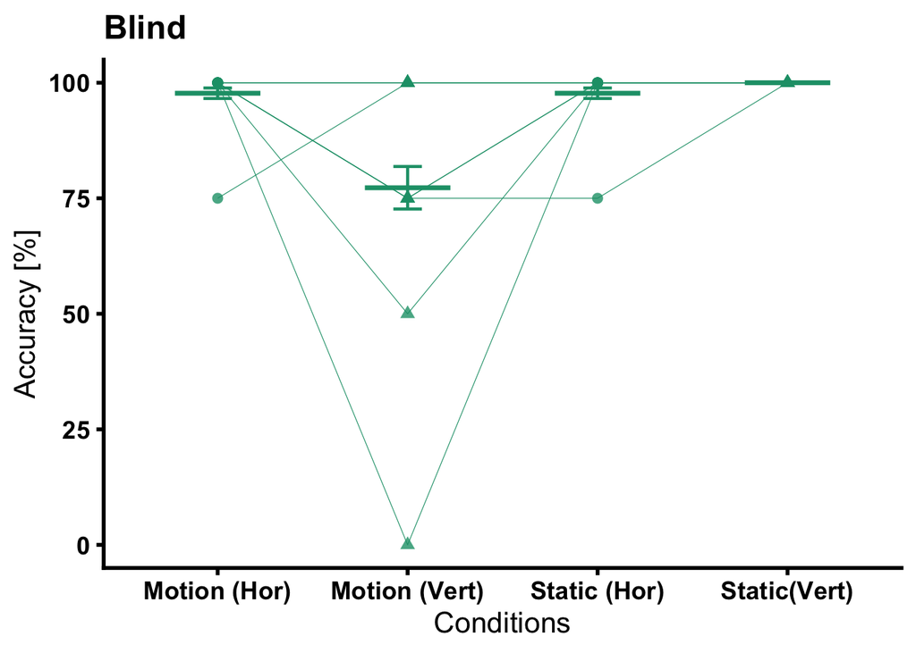

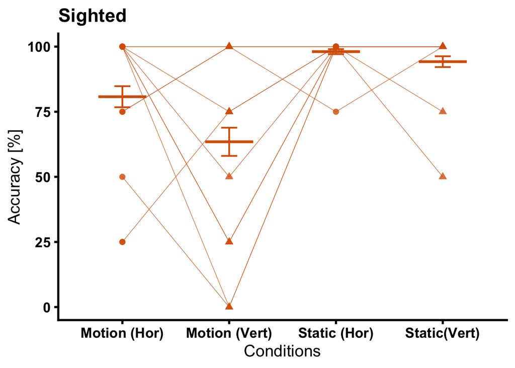

0% accuracy in vertical motion:

- sub-EB10
- sub-SC02
- sub-SC03

ANOVA 2(group: blind + sighted) x 2 (condition: motion + static) x 2 (axis: horizontal + vertical)

```
## $ANOVA
##            Effect DFn DFd           F            p p<.05         ges
## 2           group   1  20  2.78871288 0.1105081308       0.036852890
## 3            cond   1  20 15.39382537 0.0008412893     * 0.142024533
## 5            axis   1  20  5.42605865 0.0304313732     * 0.068529136
## 4      group:cond   1  20  1.48293851 0.2374880391       0.015696190
## 6      group:axis   1  20  0.23919875 0.6301059237       0.003232765
## 7       cond:axis   1  20  4.97963575 0.0372512722     * 0.056240887
## 8 group:cond:axis   1  20  0.04149696 0.8406400954       0.000496357
```

Motion is harder than static (obvious) Verical is harder than horizontal (obvious) Interaction Vertical is harder but only in motion (obvious)

CRUCIALLLY: no group differences!

## Visual Motion: behavioural accuracies

### Axis of motion pulled together (motion vs static)

Descriptive statistics across groups and conditions [% correct]

```
## # A tibble: 2 × 4
## # Groups:   group [1]
##   group cond           mean    sd
##   <chr> <fct>         <dbl> <dbl>
## 1 SC    visual_motion  96.2  6.00
## 2 SC    visual_static  99.0  3.47
```

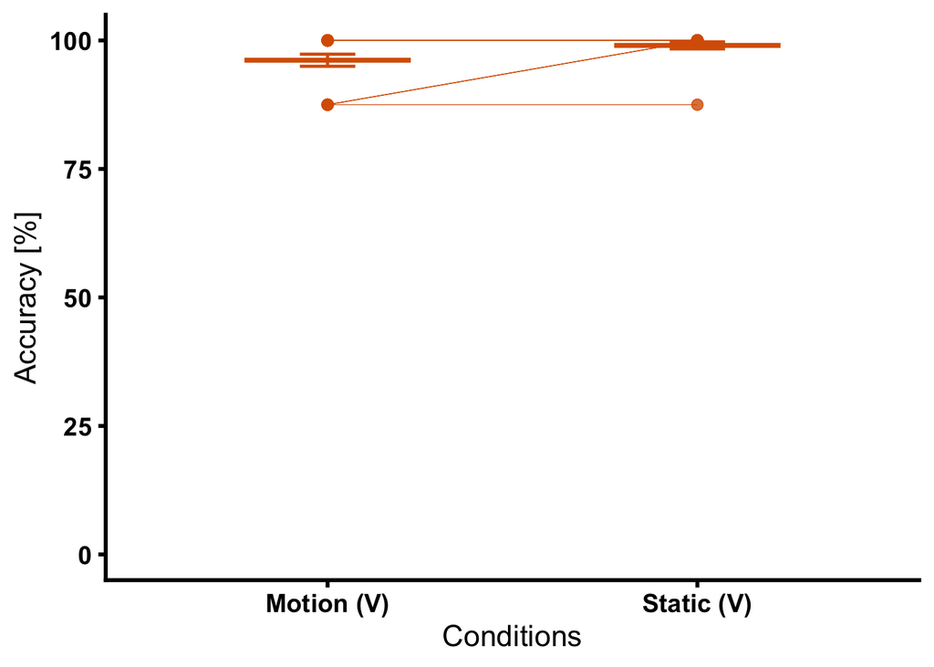

```
## $ANOVA
##   Effect DFn DFd        F          p p<.05        ges
## 2   cond   1  11 4.661017 0.05380358       0.04012841
```

Motion marginally harder than static

### Axis of motion separated (vertical vs horizontal)

```
## # A tibble: 4 × 5
## # Groups:   group, cond [2]
##   group cond          axis        mean    sd
##   <chr> <fct>         <chr>      <dbl> <dbl>
## 1 SC    visual_motion horizontal  94.2 11.0
## 2 SC    visual_motion vertical    98.1  6.93
## 3 SC    visual_static horizontal  98.1  6.93
## 4 SC    visual_static vertical   100    0
```

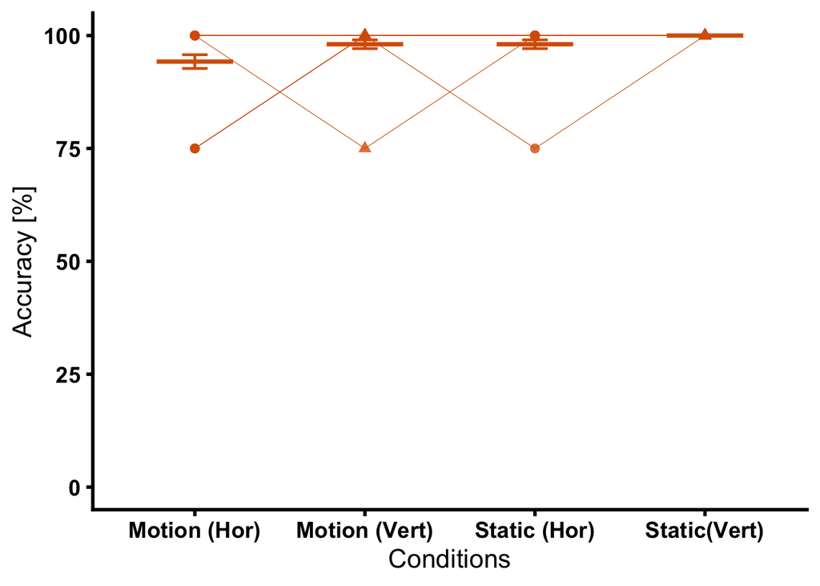

ANOVA: 2(condition) x 2 (axis) in sighted

```
## $ANOVA
##      Effect DFn DFd         F          p p<.05         ges
## 2      cond   1  11 4.6610169 0.05380358       0.030750308
## 3      axis   1  11 2.5700935 0.13720476       0.030750308
## 4 cond:axis   1  11 0.1325301 0.72272383       0.001267427
```

No effects of axis of motion (just marginal condition)